# Módulo (electivo) — El mercado laboral tiene cuatro estados, no dos: informalidad y margen de participación

**Curso complementario · puremacro**

### Objetivos de aprendizaje

Al terminar esta lección podrás:

1. Construir y leer la **matriz de transición de cuatro estados** F/I/U/N (formal / informal / desempleado / inactivo) de México con `puremacro.labor_flows_enoe`, y calcular las **tasas de encuentro y de separación por estado**.
2. **Confrontar** el modelo de búsqueda-emparejamiento de **dos estados** (E/U) —el caballo de batalla de la teoría de búsqueda, calibrado a EE.UU.— con un hecho que **no puede ver**: en una economía dual el desempleo casi no se mueve porque el ajuste cíclico corre por la **informalidad** y por el **margen de participación** (Elsby–Hobijn–Şahin 2015).
3. Entender por qué la **tasa de desempleo**, cuando más de la mitad del empleo es informal, es un termómetro de escala demasiado corta: señala el ciclo (es netamente contracíclica) pero no mide el volumen del ajuste, que ocurre en otros márgenes (Fernández–Meza 2015). Y aprender a distinguir esas dos propiedades —**amplitud** y **ciclicidad**— que suelen confundirse.

Todo corre en Python puro sobre tu **instalación local** de `puremacro` (`pip install puremacro`), leyendo los parquets **ya procesados** del bundle — nunca por red.

## 1. Dos estados no alcanzan

El modelo estándar de búsqueda (Diamond–Mortensen–Pissarides, DMP) parte de un **agente representativo** que solo puede estar en **dos estados**: empleado ($E$) o desempleado ($U$). Toda la dinámica del mercado laboral se resume en dos tasas —hallazgo de empleo $f$ y separación $s$— y la tasa de desempleo obedece $$\dot u = s\,(1-u) - f\,u, \qquad u^\* = \frac{s}{s+f}.$$ Ese marco describe razonablemente a EE.UU. Pero proyectarlo sobre México ignora dos márgenes que allí **son el centro de la acción**:

- **Informalidad (I).** Estar empleado no es un estado único: hay empleo **formal** (con acceso a seguridad social vía el empleador) e **informal** (sin él). En México el empleo informal es **más de la mitad** del total.
- **Participación (N).** La frontera entre buscar trabajo y salir de la fuerza laboral es porosa. Elsby, Hobijn y Şahin (2015) muestran que ignorar este **margen de participación** sesga cualquier lectura de las fluctuaciones.

`puremacro.labor_flows_enoe` codifica los **cuatro** estados `STATES = ('F', 'I', 'U', 'N')` a partir del panel rotatorio de la ENOE (INEGI).

> **Aviso de notación.** En el bloque de tres estados E/U/I de EE.UU. (la CPS), la letra $I$ significa **inactividad**. Aquí, en el bloque mexicano F/I/U/N, $I$ es empleo **informal** y la inactividad pasa a $N$. Es la misma convención del mazo del curso; no las mezcles.

### Los datos del bundle

El microdato de la ENOE (cientos de MB por trimestre) **no** viaja en el bundle, así que `transitions_from_enoe` / `load_enoe_quarter` —que leen los `.dta` de INEGI— quedan fuera de esta lección. Lo que sí traemos, **ya procesado** por esa tubería, son dos parquets: las **transiciones trimestrales observadas** (matriz $4\times4$ por mes de referencia) y los **acervos mensuales** F/I/U/N. Trabajamos con ellos.

```python
# Dos requisitos que conviene comprobar ANTES de nada, porque fallan de forma poco
# informativa: (i) el módulo labor_flows_enoe, que no está en todas las ruedas publicadas
# de puremacro; (ii) un motor de parquet (pyarrow o fastparquet), que pandas necesita para
# read_parquet y que no viene con las dependencias base del paquete.
try:
    from puremacro.labor_flows_enoe import STATES   # ('F', 'I', 'U', 'N')
except ModuleNotFoundError:                          # rueda de PyPI sin este módulo
    STATES = ("F", "I", "U", "N")
    print("AVISO: puremacro.labor_flows_enoe no está en tu instalación de puremacro.\n"
          "       La lección sigue: los cuatro estados se declaran aquí y los datos ya\n"
          "       vienen procesados en el bundle. Para tener el módulo, instala puremacro\n"
          "       desde el árbol del repositorio (`pip install -e .`) en vez de PyPI.")
try:
    import pyarrow  # noqa: F401  -- motor de parquet
except ModuleNotFoundError:
    try:
        import fastparquet  # noqa: F401
    except ModuleNotFoundError as _e:
        raise ModuleNotFoundError(
            "Esta lección lee dos archivos .parquet y pandas necesita un motor para ello. "
            "Instala uno con `pip install pyarrow` (o `pip install fastparquet`) y vuelve "
            "a ejecutar la celda."
        ) from _e

tr = pd.read_parquet(DATA / "enoe_transitions_quarterly_observed.parquet")  # p_ab por mes
st = pd.read_parquet(DATA / "enoe_stocks_monthly.parquet")                  # F/I/U/N (personas)
print(f"transiciones: {tr.shape[0]} meses de referencia, {tr.index.min().date()} .. {tr.index.max().date()}")
print(f"acervos:      {st.shape[0]} meses, estados = {list(st.columns)}")
print(f"estados del módulo: {STATES}")

# Matriz de transición trimestral MEDIA (cada p_ab es Prob(j en t | i en t-3)).
# La suspensión de la ENOE (abril-junio de 2020) deja fuera 6 meses de referencia: 3 no
# están en el índice (feb.-abr. 2020) y 3 vienen enmascarados como NaN (ene., may. y jun.
# de 2020), que .mean() de pandas ignora. La media se calcula, pues, sobre 229 meses.
P = np.array([[tr[f"p_{a}{b}"].mean() for b in STATES] for a in STATES])
print("\nmatriz de transición media 4x4 (filas suman a 1):", P.sum(axis=1).round(3))
assert np.allclose(P.sum(axis=1), 1.0, atol=1e-6)
```

```
transiciones: 232 meses de referencia, 2005-04-01 .. 2024-10-01
acervos:      234 meses, estados = ['F', 'I', 'U', 'N']
estados del módulo: ('F', 'I', 'U', 'N')

matriz de transición media 4x4 (filas suman a 1): [1. 1. 1. 1.]
```

### Tasas de encuentro y de separación, **por estado**

Con cuatro estados, "encontrar empleo" y "separarse" dejan de ser dos números y se vuelven **flujos por origen**. Definimos (todo trimestral):

- **Encuentro** hacia el empleo ($F\cup I$): desde $U$, $f_U=p_{UF}+p_{UI}$; desde $N$, $f_N=p_{NF}+p_{NI}$.
- **Separación** hacia el no-empleo ($U\cup N$): desde $F$, $s_F=p_{FU}+p_{FN}$; desde $I$, $s_I=p_{IU}+p_{IN}$.
- **Rotación dual**: formalización $p_{IF}$ e informalización $p_{FI}$ —el churn $F\leftrightarrow I$ que un modelo de dos estados colapsa en "empleo".

```python
f_U = (tr["p_UF"] + tr["p_UI"]).mean()   # U -> empleo
f_N = (tr["p_NF"] + tr["p_NI"]).mean()   # N -> empleo
s_F = (tr["p_FU"] + tr["p_FN"]).mean()   # F -> no-empleo
s_I = (tr["p_IU"] + tr["p_IN"]).mean()   # I -> no-empleo
p_IF = tr["p_IF"].mean()                 # formalización
p_FI = tr["p_FI"].mean()                 # informalización

print("ENCUENTRO (hacia empleo, trimestral)")
print(f"  desde U:  f_U = p_UF+p_UI = {f_U:.3f}")
print(f"  desde N:  f_N = p_NF+p_NI = {f_N:.3f}")
print("SEPARACIÓN (hacia no-empleo, trimestral)")
print(f"  desde F:  s_F = p_FU+p_FN = {s_F:.3f}")
print(f"  desde I:  s_I = p_IU+p_IN = {s_I:.3f}   <- el empleo informal es mucho más frágil")
print("ROTACIÓN DUAL")
print(f"  formalización   I->F = {p_IF:.3f}")
print(f"  informalización F->I = {p_FI:.3f}   <- salir hacia informalidad es más probable que formalizarse")
assert s_I > s_F        # el empleo informal se separa mucho más que el formal
assert p_FI > p_IF      # hazards, no flujo neto: la tasa de formalización (I->F) es baja — la informalidad no es un trampolín fácil
```

```
ENCUENTRO (hacia empleo, trimestral)
  desde U:  f_U = p_UF+p_UI = 0.516
  desde N:  f_N = p_NF+p_NI = 0.146
SEPARACIÓN (hacia no-empleo, trimestral)
  desde F:  s_F = p_FU+p_FN = 0.063
  desde I:  s_I = p_IU+p_IN = 0.186   <- el empleo informal es mucho más frágil
ROTACIÓN DUAL
  formalización   I->F = 0.100
  informalización F->I = 0.153   <- salir hacia informalidad es más probable que formalizarse
```

### Figura 1 — la matriz $4\times4$ y sus tasas por estado

Izquierda: la matriz de transición media (más oscuro = más probable). La **diagonal** domina —cada estado es persistente ($p_{FF}=0.78$, $p_{II}=0.71$, $p_{NN}=0.84$), salvo $U$, que no lo es ($p_{UU}=0.19$)—, y en la fila $I$ compara las dos salidas que importan: $p_{IN}=0.17$ contra $p_{IF}=0.10$. La informalidad desemboca en inactividad más que en formalidad.

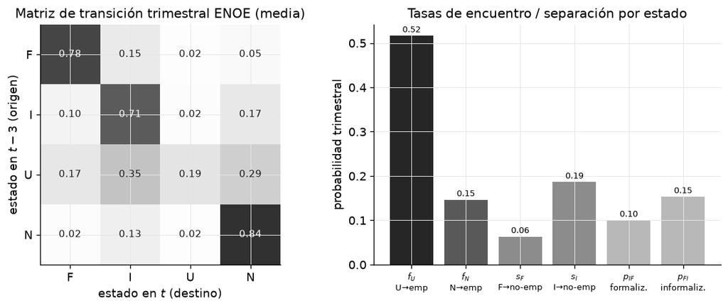

```python
fig, axes = plt.subplots(1, 2, figsize=(10.0, 4.1))

ax = axes[0]
im = ax.imshow(P, cmap="Greys", vmin=0, vmax=1, aspect="equal")
ax.set_xticks(range(4)); ax.set_xticklabels(STATES)
ax.set_yticks(range(4)); ax.set_yticklabels(STATES)
ax.set_xlabel("estado en $t$ (destino)"); ax.set_ylabel("estado en $t-3$ (origen)")
ax.set_title("Matriz de transición trimestral ENOE (media)")
for i in range(4):
    for j in range(4):
        ax.text(j, i, f"{P[i, j]:.2f}", ha="center", va="center",
                color="white" if P[i, j] > 0.5 else "0.10", fontsize=9)

ax = axes[1]
labels = ["$f_U$\nU→emp", "$f_N$\nN→emp", "$s_F$\nF→no-emp", "$s_I$\nI→no-emp",
          "$p_{IF}$\nformaliz.", "$p_{FI}$\ninformaliz."]
vals = [f_U, f_N, s_F, s_I, p_IF, p_FI]
grays = ["0.15", "0.35", "0.55", "0.55", "0.72", "0.72"]
ax.bar(range(len(vals)), vals, color=grays)
ax.set_xticks(range(len(vals))); ax.set_xticklabels(labels, fontsize=8)
ax.set_ylabel("probabilidad trimestral")
ax.set_title("Tasas de encuentro / separación por estado")
for i, v in enumerate(vals):
    ax.text(i, v + 0.008, f"{v:.2f}", ha="center", fontsize=8)
plt.tight_layout(); plt.show()
```

**Lectura.** El desempleo $U$ es un estado **pequeño y de paso**: solo el 19% de quienes están en $U$ siguen ahí un trimestre después ($p_{UU}=0.19$), y de los que salen hacia el empleo ($f_U\approx0.52$) el destino **no** es indistinto: entran a la informalidad **el doble de veces** que a la formalidad ($p_{UI}=0.35$ contra $p_{UF}=0.17$). El grueso del ajuste ocurre además **sin pasar por el desempleo**: la separación del empleo informal ($s_I=0.19$) casi triplica la del formal ($s_F=0.06$), y buena parte de esos flujos van directo a la **inactividad** ($N$), no a la fila de desempleo. Un modelo E/U no tiene dónde poner ninguno de estos movimientos.

## 2. La confrontación: el desempleo que casi no se mueve

El DMP de dos estados, calibrado a EE.UU., hace del **desempleo** la variable de estado que absorbe el ciclo: cae en las expansiones, salta en las recesiones. Si aplicamos esa lente a México deberíamos ver un desempleo que absorbe el ciclo con **amplitud** comparable. **No lo vemos.** Cuidado con la formulación, que es donde se cuela el error fácil: lo que falla no es que $u$ no *siga* al ciclo —lo sigue, y muy de cerca, como mediremos—, sino que su recorrido es demasiado corto para dar cabida al ajuste. Comparemos la tasa de desempleo de EE.UU. (el mundo de dos estados) con la de México, calculada desde los acervos $u = U/(F+I+U)$, en la **misma ventana** 2005–2024.

```python
from puremacro.data import hp_filter   # (cycle, trend) = hp_filter(y, lamb=1600)

# México: márgenes desde los acervos (trimestral, promediando los meses).
# OJO con el hueco: la ENOE se suspendió en abril-junio de 2020, así que 2020Q2 no existe
# en los acervos y .dropna() lo elimina. La serie trimestral queda con 78 observaciones y
# el filtro HP la trata como si fuera contigua (2020Q1 pegado a 2020Q3).
q = st.resample("QS").mean().dropna()
LF  = q["F"] + q["I"] + q["U"]            # fuerza laboral
WAP = LF + q["N"]                         # población en edad de trabajar
u_mx   = 100 * q["U"] / LF               # tasa de desempleo (% de la PEA)
infml  = 100 * q["I"] / (q["F"] + q["I"])  # informalidad (% del empleo)
inact  = 100 * q["N"] / WAP               # inactividad (% de la WAP) = margen de participación

# EE.UU.: tasa de desempleo congelada del bundle (FRED UNRATE), misma ventana.
us = pd.read_csv(DATA / "UNRATE.csv"); us.columns = ["date", "u"]
us["date"] = pd.to_datetime(us["date"]); us = us.set_index("date")["u"].resample("QS").mean()
lo, hi = u_mx.index.min(), u_mx.index.max()
u_us = us[(us.index >= lo) & (us.index <= hi)]

def hp_cycle(x):
    """Componente cíclico HP (lambda=1600) como array."""
    c, _ = hp_filter(np.asarray(x, dtype=float)); return np.asarray(c, dtype=float)

def cyc_sd(x):
    """Desviación estándar del ciclo HP (lambda=1600)."""
    return float(np.std(hp_cycle(x)))

sd = {"u EE.UU.": cyc_sd(u_us), "u México": cyc_sd(u_mx),
      "informalidad": cyc_sd(infml), "inactividad": cyc_sd(inact)}
print("nivel medio:  u_MX = %.1f%%   informalidad = %.0f%% del empleo   participación = %.0f%% de la WAP"
      % (u_mx.mean(), infml.mean(), 100 - inact.mean()))
print("volatilidad cíclica (sd del ciclo HP), CADA UNA SOBRE SU PROPIA BASE:")
for k, base in [("u EE.UU.", "% de la PEA "), ("u México", "% de la PEA "),
                ("informalidad", "% del empleo"), ("inactividad", "% de la WAP ")]:
    print(f"  {k:14s} {base}  {sd[k]:.2f}")

# --- Base COMÚN. Los cuatro números de arriba tienen DENOMINADORES DISTINTOS (PEA, empleo,
# WAP), así que sus "puntos %" no son comparables entre sí tal cual. La comparación limpia
# expresa los cuatro estados mexicanos como % de la MISMA población: la WAP.
sd_wap = {s: cyc_sd(100 * q[s] / WAP) for s in STATES}
print("\nbase COMÚN (los cuatro estados como % de la WAP), sd del ciclo HP:")
for s in STATES:
    print(f"  {s}: {sd_wap[s]:.2f}")
print(f"  -> I se mueve {sd_wap['I']/sd_wap['U']:.1f}x más que U, y N {sd_wap['N']/sd_wap['U']:.1f}x más:")
print( "     el orden se mantiene en base común, no era un artefacto de los denominadores.")
rho_FI = float(np.corrcoef(hp_cycle(100 * q["F"] / WAP), hp_cycle(100 * q["I"] / WAP))[0, 1])
print(f"  corr(ciclo F/WAP, ciclo I/WAP) = {rho_FI:.2f}  <- F e I son imágenes espejo:")
print( "     el volumen del movimiento está en la recomposición F<->I, no en la entrada a U")
print( "     (si ese movimiento es o no ciclo agregado, lo medimos en la celda siguiente).")

# --- Cociente EE.UU./México: dos lecturas, porque las muestras NO son idénticas.
# 2020Q2 (el trimestre de u=13.0% en EE.UU.) falta en México: la ENOE estaba suspendida.
r_todo = sd["u EE.UU."] / sd["u México"]
sin20  = lambda x: x[x.index.year != 2020]
r_sin20 = cyc_sd(sin20(u_us)) / cyc_sd(sin20(u_mx))
print(f"\ncociente sd(u EE.UU.)/sd(u México) = {r_todo:.1f}x  (muestra completa; EE.UU. incluye")
print( "  el 2020Q2 de 13.0% que en México no existe porque la ENOE estuvo suspendida)")
print(f"  excluyendo 2020 en AMBOS países:    {r_sin20:.1f}x  <- el contraste sobrevive, más modesto")
assert sd["u EE.UU."] > sd["u México"]     # el 2-estados de EUA vive de un u volátil
assert r_sin20 > 1.0                       # y no es un artefacto del COVID asimétrico
assert min(sd_wap, key=sd_wap.get) == "U"  # en base común, U es el margen MENOS volátil
assert rho_FI < -0.5                       # el ajuste es la recomposición F<->I
assert infml.mean() > 50                   # economía dual: >50% del empleo es informal
```

```
nivel medio:  u_MX = 4.0%   informalidad = 62% del empleo   participación = 56% de la WAP
volatilidad cíclica (sd del ciclo HP), CADA UNA SOBRE SU PROPIA BASE:
  u EE.UU.       % de la PEA   1.30
  u México       % de la PEA   0.41
  informalidad   % del empleo  1.91
  inactividad    % de la WAP   0.70

base COMÚN (los cuatro estados como % de la WAP), sd del ciclo HP:
  F: 1.13
  I: 1.04
  U: 0.22
  N: 0.70
  -> I se mueve 4.7x más que U, y N 3.2x más:
     el orden se mantiene en base común, no era un artefacto de los denominadores.
  corr(ciclo F/WAP, ciclo I/WAP) = -0.74  <- F e I son imágenes espejo:
     el volumen del movimiento está en la recomposición F<->I, no en la entrada a U
     (si ese movimiento es o no ciclo agregado, lo medimos en la celda siguiente).

cociente sd(u EE.UU.)/sd(u México) = 3.2x  (muestra completa; EE.UU. incluye
  el 2020Q2 de 13.0% que en México no existe porque la ENOE estuvo suspendida)
  excluyendo 2020 en AMBOS países:    2.1x  <- el contraste sobrevive, más modesto
```

### Amplitud no es ciclicidad: correlación con el PIB

Lo anterior mide **cuánto se mueve** cada margen, no **con qué** se mueve. Son preguntas distintas y aquí dan respuestas distintas, así que conviene medir las dos. Correlacionamos el ciclo HP de cada margen con el ciclo HP del **PIB mexicano** (OCDE QNA, volúmenes, CSV congelado del bundle; para México la OCDE solo publica base fija `Q`, por eso se lee el CSV y no `fetch_qna_expenditure`).

```python
_qna = pd.read_csv(DATA / "oecd_qna_apertura.csv")
_gdp = (_qna[(_qna["code"] == "MEX") & (_qna["variable"] == "gdp_vol")]
        .assign(date=lambda d: pd.to_datetime(d["date"])).set_index("date")["value"].sort_index())
com = _gdp.index.intersection(q.index)          # ventana común: 78 trimestres (sin 2020Q2)
c_gdp = hp_cycle(100 * np.log(_gdp.loc[com]))   # ciclo del PIB, en % (log x 100)

rho = {"u México (% PEA)": np.corrcoef(c_gdp, hp_cycle(u_mx.loc[com]))[0, 1]}
for s in STATES:
    rho[f"{s}/WAP"] = float(np.corrcoef(c_gdp, hp_cycle(100 * q[s].loc[com] / WAP.loc[com]))[0, 1])
rho["informalidad (% empleo)"] = float(np.corrcoef(c_gdp, hp_cycle(infml.loc[com]))[0, 1])

print(f"ciclo del PIB de México: sd = {np.std(c_gdp):.2f}%  ({len(com)} trimestres, 2005Q2-2024Q4)")
print("correlación contemporánea con el ciclo del PIB:")
for k, v in rho.items():
    print(f"  {k:24s} {v:+.2f}")
print("\nLECTURA, y corrige la intuición fácil:")
print("  * la tasa de desempleo mexicana NO es acíclica: es el margen MÁS contracíclico")
print("    de los cuatro. Registra el ciclo con fidelidad; lo que no hace es ABSORBERLO,")
print("    porque su amplitud es minúscula (0.22 pp de la WAP).")
print("  * la inactividad N es claramente contracíclica: en las recesiones la gente sale")
print("    de la fuerza laboral. Ése es el margen de participación de Elsby-Hobijn-Sahin.")
print("  * el par F<->I es el de mayor amplitud (1.13 y 1.04 pp de la WAP: dos caras de un")
print("    mismo margen, corr = -0.74) pero el MENOS alineado con el PIB:")
print("    buena parte de su movimiento no es ciclo agregado (composición, reformas,")
print("    formalización de largo plazo). Amplitud grande no implica ciclicidad grande.")
assert rho["u México (% PEA)"] < -0.5           # u es contracíclica y con fuerza
assert abs(rho["informalidad (% empleo)"]) < abs(rho["u México (% PEA)"])
assert rho["N/WAP"] < 0                         # la participación cae en las recesiones
```

```
ciclo del PIB de México: sd = 2.05%  (78 trimestres, 2005Q2-2024Q4)
correlación contemporánea con el ciclo del PIB:
  u México (% PEA)         -0.76
  F/WAP                    +0.29
  I/WAP                    +0.19
  U/WAP                    -0.72
  N/WAP                    -0.51
  informalidad (% empleo)  -0.12

LECTURA, y corrige la intuición fácil:
  * la tasa de desempleo mexicana NO es acíclica: es el margen MÁS contracíclico
    de los cuatro. Registra el ciclo con fidelidad; lo que no hace es ABSORBERLO,
    porque su amplitud es minúscula (0.22 pp de la WAP).
  * la inactividad N es claramente contracíclica: en las recesiones la gente sale
    de la fuerza laboral. Ése es el margen de participación de Elsby-Hobijn-Sahin.
  * el par F<->I es el de mayor amplitud (1.13 y 1.04 pp de la WAP: dos caras de un
    mismo margen, corr = -0.74) pero el MENOS alineado con el PIB:
    buena parte de su movimiento no es ciclo agregado (composición, reformas,
    formalización de largo plazo). Amplitud grande no implica ciclicidad grande.
```

### Ficha de medición (regla del curso: ningún segundo momento sin sus seis campos)

[output not shown]

**Y una advertencia de nivel.** Estas cifras salen del panel rotatorio con sus propias definiciones y pesos, así que **no coinciden con los agregados publicados por INEGI**: la tasa de informalidad laboral oficial (TIL1) ronda 55–58% y la tasa de participación de la ENOE ~59.5%, frente al 62% y 56% de aquí. Para el argumento de la lección importan el **orden de magnitud** y la **volatilidad relativa**, no el decimal del nivel.

### Figura 2 — lo que el modelo de dos estados ve, y lo que se pierde

Izquierda: la línea que el DMP de dos estados toma como *todo* el mercado laboral —el desempleo— en EE.UU. y en México. Derecha: la volatilidad cíclica de los cuatro estados mexicanos **en base común** (todos como % de la misma población, la WAP), que es la única forma de compararlos entre sí. En México el desempleo es, con diferencia, el margen **menos** volátil.

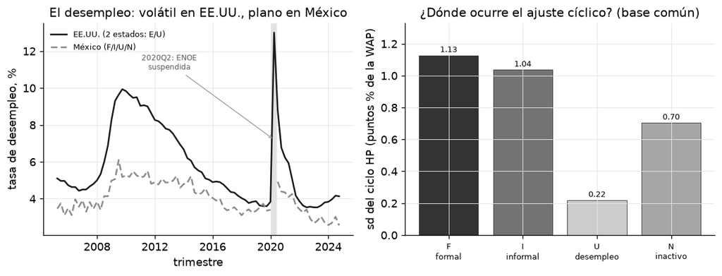

```python
fig, axes = plt.subplots(1, 2, figsize=(10.0, 3.9))

ax = axes[0]
# Reindexar México al calendario trimestral completo deja 2020Q2 como NaN, de modo que la
# línea se ROMPE en el hueco de la ENOE en vez de fingir una interpolación que no existe.
u_mx_plot = u_mx.reindex(pd.date_range(u_mx.index.min(), u_mx.index.max(), freq="QS"))
ax.plot(u_us.index, u_us.values, color="0.10", lw=1.6, label="EE.UU. (2 estados: E/U)")
ax.plot(u_mx_plot.index, u_mx_plot.values, color="0.55", lw=1.6, ls=(0, (4, 2)),
        label="México (F/I/U/N)")
ax.axvline(pd.Timestamp("2020-04-01"), color="0.75", lw=6, alpha=0.45, zorder=0)
ax.annotate("2020Q2: ENOE\nsuspendida", xy=(pd.Timestamp("2020-04-01"), 7.2),
            xytext=(pd.Timestamp("2013-01-01"), 11.0), fontsize=7, color="0.35",
            ha="center", arrowprops=dict(arrowstyle="->", color="0.6", lw=0.8))
ax.set_ylabel("tasa de desempleo, %"); ax.set_xlabel("trimestre")
ax.set_title("El desempleo: volátil en EE.UU., plano en México")
ax.legend(fontsize=8, loc="upper left")

ax = axes[1]
order = ["F", "I", "U", "N"]
names = ["F\nformal", "I\ninformal", "U\ndesempleo", "N\ninactivo"]
ax.bar(range(len(order)), [sd_wap[k] for k in order],
       color=["0.20", "0.45", "0.80", "0.65"], edgecolor="0.25", lw=0.6)
ax.set_xticks(range(len(order))); ax.set_xticklabels(names, fontsize=8)
ax.set_ylabel("sd del ciclo HP (puntos % de la WAP)")
ax.set_title("¿Dónde ocurre el ajuste cíclico? (base común)")
ax.set_ylim(0, max(sd_wap.values()) * 1.18)
for i, k in enumerate(order):
    ax.text(i, sd_wap[k] + 0.02, f"{sd_wap[k]:.2f}", ha="center", fontsize=8)
plt.tight_layout(); plt.show()
```

**El puñetazo.** En EE.UU. el desempleo trimestral salta de 3.6% (2019Q4) a **13.0%** (2020Q2) y de 4.8% (2007Q4) a **9.9%** (2009Q4): el modelo E/U calibrado a esos datos *necesita* un $u$ muy cíclico. En México, en las mismas fechas, la tasa de desempleo se mueve en una banda estrecha alrededor de su media de 4.0%: su **máximo de toda la muestra** es 6.1% (2009Q3) y en el trimestre COVID medido (2020Q3) llega solo a 4.9%. No es que el mercado laboral mexicano no fluctúe: fluctúa por **otros márgenes**. En base común, el de mayor amplitud es la recomposición formal↔informal (1.13 y 1.04 pp de la WAP: son dos caras del mismo margen, con correlación $-0.74$ entre sus ciclos), casi cinco veces el desempleo; la participación (entrar/salir de $N$) le sigue, con más del triple. Ojo con el salto lógico que ya desmontamos arriba: *amplitud* no es *ciclicidad*. La que marca el ciclo con fidelidad es $u$ ($-0.76$ con el PIB); la que mueve gente es la informalidad. Y la que hace las dos cosas a la vez —amplitud grande y signo claro ($-0.51$)— es la **inactividad**: es exactamente el **margen de participación** de Elsby–Hobijn–Şahin (2015), amplificado por la dualidad formal/informal (Fernández–Meza 2015). Un modelo de dos estados, estructuralmente, **no tiene la fila ni la columna** para registrarlo.

*Dos cautelas honestas.* (i) El trimestre más violento del episodio COVID (2020Q2) está en la serie de EE.UU. y **falta** en la de México, así que el cociente de volatilidades de la muestra completa exagera el contraste; por eso la celda de arriba lo recalcula excluyendo 2020 en ambos países y el contraste sobrevive, aunque más modesto. (ii) La comparación entre márgenes solo tiene sentido con **denominador común**: en puntos porcentuales de bases distintas (PEA, empleo, WAP) uno puede fabricar casi cualquier ordenamiento.

### Figura 3 — el desempleo es una rendija

Composición de la población en edad de trabajar por estado. La banda de **desempleo (U)** es una rendija delgada y quieta; el volumen y el movimiento están en $F$, $I$ y $N$. Ahí es donde vive el ciclo laboral mexicano.

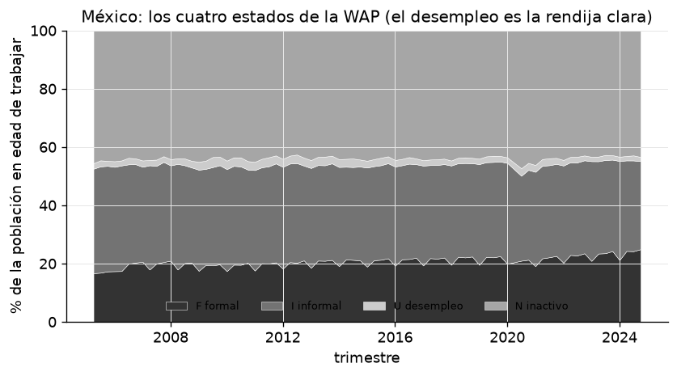

```
la banda U promedia solo 2.3% de la WAP;  I promedia 33%  y  N promedia 44%
```

```python
shares = q[list(STATES)].div(WAP, axis=0) * 100.0   # % de la WAP, por estado
fig, ax = plt.subplots(figsize=(8.0, 3.9))
ax.stackplot(shares.index,
             shares["F"], shares["I"], shares["U"], shares["N"],
             labels=["F formal", "I informal", "U desempleo", "N inactivo"],
             colors=["0.20", "0.45", "0.80", "0.65"], edgecolor="white", lw=0.3)
ax.set_ylim(0, 100); ax.set_ylabel("% de la población en edad de trabajar")
ax.set_xlabel("trimestre")
ax.set_title("México: los cuatro estados de la WAP (el desempleo es la rendija clara)")
ax.legend(loc="lower center", ncol=4, fontsize=8, framealpha=0.9)
plt.show()

u_band = shares["U"].mean()
print(f"la banda U promedia solo {u_band:.1f}% de la WAP;  I promedia {shares['I'].mean():.0f}%  y  N promedia {shares['N'].mean():.0f}%")
```

## 3. Preguntas para pensar

1. **¿Qué mide la tasa de desempleo con ~62% de informalidad?** Si perder el empleo formal casi nunca lleva a "desempleado que busca" sino a "informal" o a "inactivo", ¿un desempleo de 4% significa pleno empleo, o significa que el desempleo abierto es un lujo que pocos pueden pagarse? ¿Qué indicador pondrías en su lugar para leer el ciclo laboral mexicano?
2. **El agente representativo.** El DMP de dos estados tiene un solo tipo de trabajador y un solo tipo de empleo. ¿Qué supuesto exacto se rompe al añadir el estado $I$: la matching function, la ecuación de Bellman del empleo, o la regla de reparto salarial (Nash)? ¿Bastaría con "dos sectores DMP en paralelo" o hace falta permitir flujos $F\leftrightarrow I$?
3. **Margen de participación.** Elsby–Hobijn–Şahin (2015) descomponen las fluctuaciones incluyendo entradas/salidas de la fuerza laboral. En la Figura 2, la inactividad es más volátil que el desempleo (más del triple, en base común). ¿Por qué un modelo que fija la participación —uno en el que toda la población relevante es la fuerza laboral, $E+U$, sin estado $N$— atribuiría erróneamente ese movimiento a la tasa de hallazgo $f$ o a la de separación $s$?

## 4. Explora con IA

Prueba esto con el tutor sin conexión (o cualquier asistente de IA):

- "¿Por qué en una economía con alta informalidad la tasa de desempleo subestima el deterioro del mercado laboral en una recesión? Responde en una frase."
- "¿Qué le falta a un modelo de búsqueda de dos estados (E/U) para representar el margen de participación de Elsby–Hobijn–Şahin?"

```python
print(tutor("En una frase: ¿por qué la tasa de desempleo mide mal el ciclo "
            "laboral en una economía con más de la mitad del empleo informal?"))
```

```
[tutor sin conexión] No hay ningún motor de LLM local disponible en esta instalación (el tutor es opcional). Puedes instalar uno con `pip install puremacro[local-llm]` más un modelo pequeño (por ejemplo vía Ollama o MLX), o bien usar las indicaciones de la sección «Explora con IA» de esta lección co…
(motivo: el motor local no está disponible)
```

**Referencias.** Elsby, Hobijn y Şahin (2015), *On the importance of the participation margin for labor market fluctuations*, JME 72. · Shimer (2012), *Reassessing the ins and outs of unemployment*, RED 15. · Fernández y Meza (2015), *Informal employment and business cycles in emerging economies: The case of Mexico*, RED 18.